# Notebook 08 – Solutions

## Getting Started

Before running this notebook, select “Session > Restart R and Clear Output” in the menu above to start a new R session. This will clear any old data sets and give us a blank slate to start with.

After starting a new session, run the following code chunk to load the libraries and data that we will be working with today.

I have set the options `include=FALSE` and `message=FALSE` to avoid cluttering the solutions with all the output from this code.

# Storytelling with Data

## Overview

Most classes in statistics and data science spend a lot of time discussing and practicing the technical skills of working with data, such as building complex graphics, collecting and cleaning data, and building inferential and predictive models. Often little to no time is spent discussing how to present and use the output of these analyses. Today’s notes are an attempt to partially rectify this. We will continue to make the presentation of our data a part of our discussion throughout the course.

Today’s material comes from a number of sources, which I suggest you check out if you are interested in studying these topics further. Specifically:

- *Storytelling with Data* by Cole Nussbaumer Knaflic
- *The Visual Display of Quantitative Information* by Edward Tufte
- *Beautiful Evidence* by Edward Tufte
- *The Functional Art* by Alberto Cairo
- *Dear Data* by Giorgia Lupi and Stefanie Posavec

I can share digital copies of these with students who are interested.

These notes are a very opinionated set of recommendations for how to start thinking about telling stories with data. Feel free to deviate from these suggestions in your work as need, though be prepared to explain why you choose to do something different. Note that the notes here are strictly about doing *explanatory* analysis; this is the mode where we want to convey a specific point of information to our audience. This differs from an exploratory presentation, where we expect the audience to help discover new things in the dataset. Many of the recommendations are different for these two modes, if not entirely contradictory.

In the following sections we will discuss the process of telling a story with data from four perspectives:

1. Choosing effective visuals
2. Reducing clutter
3. Focusing attention
4. Use narrative logic

Each of these are discussed below.

### Choosing effective visuals

We have discussed a number of methods for producing graphics to describe our data, but have not spent much time talking about the specific uses of each graphic type. Here is a non-exhaustive list of common use-cases for some of the methods we have seen so far:

- **scatterplot**’s are good at showing the relationship between two variables when at least on variable is continuous; they become hard to read when there are more than a few hundred points (or less if the data are heavily clustered); also useful for showing spatial data
- **scatterplot with bestfit line** can be used to suggest a more model based relationship between two variables
- **line plot** is useful for showing the relationship between time (almost always on the x-axis) and another continuous output; can show multiple lines on the same plot when needed
- **slopegraph** is a line plot with only two points on the x-axis; this is a favorite in business analyses for showing the change of variables from one point in time to another
- **bar plot** shows the relationship between a summary statistic and a categorical variable; often used to show counts, but also useful to show sums, means, and other concrete numeric variables
- **confidence interval plot** show the average value of a continuous variable in relationship with a discrete variable
- **histogram**, **box-plot**, **ribbon plot** all show the distribution of a continuous variable; these can be confusing for non-technical audiences, but are good for some applications where the specific distribution is important
- **numbers** one or two numbers can often serve as the best way to describe the output of a dataset; don’t overlook this in cases where other methods only complicate the story
- **tables** also have their uses, particularly when presenting the results of a regression analysis to a technical audience; I would generally avoid, however, with oral presentations as tables can be too difficult to interpret on the fly

Most of these have been shown in the previous notebooks. Those that have not consist of using a slightly different geometry, but follow from the same principles that we have already developed.

### Reduce clutter

As mentioned in the notes from last class, when presenting data visualizations it is important to reduce clutter. That is, we should aim to remove any element of a plot that is not relevant to the overall message.

Here are some strategies to reduce clutter in plots:

1. Use minimal themes, such as `theme_sm` or, if you think gridlines are useful, try `theme_minimal`.
2. Make sure that categories have a natural ordering; this can be achieved by using `fct_inorder` with `arrange`, or `factor` with manually defined levels.
3. If possible and logical, reduce the number of categories using `fct_lump`.
4. Avoid if possible with `show.legend = FALSE`. For size, consider using easily described scales, such as `scale_size_area`.
5. Consider using a logarithmic or sqrt scale for the x and y axis if it better spreads out the dataset.
6. Consider using the function `slice_sample` to show or label only a subset of the data if there are otherwise too many points.

There are also a number of strategies involving color that we will discuss in another section.

Here is an example of how to reduce the clutter in a plot that uses size to show the number of food items in each food group:

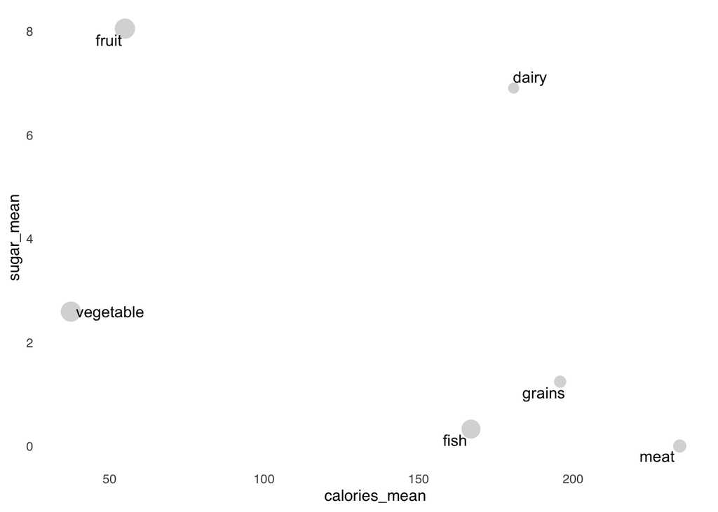

```r
food %>%
  group_by(food_group) %>%
  summarize(sm_mean(sugar), sm_mean(calories), sm_count()) %>%
  ggplot(aes(calories_mean, sugar_mean)) +
    geom_point(aes(size = count), color = "grey85", show.legend = FALSE) +
    geom_text_repel(aes(label = food_group)) +
    scale_size_area() +
    theme_sm()
```

And here is an example of using sampling to reduce clutter in a scatter plot:

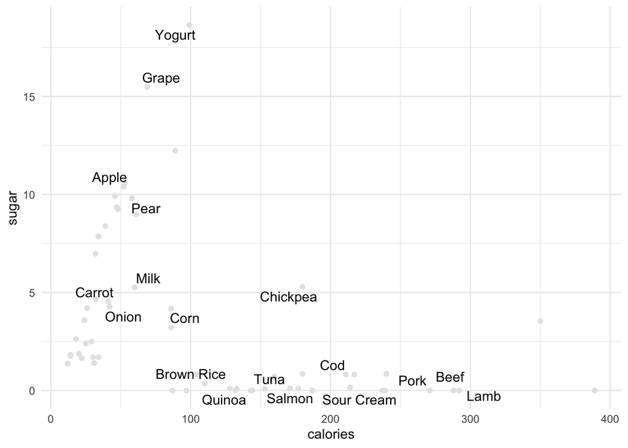

```r
# grab three random foods from each food group
food_sample <- food %>%
  group_by(food_group) %>%
  slice_sample(n = 3)

food %>%
  ggplot(aes(calories, sugar)) +
    geom_point(color = "grey90") +
    geom_text_repel(aes(label = item), data = food_sample)
```

Notice that the previous plot will change each time you run the code. To stop this, you can add `set.seed(1)` to fix the sampling. Change the number `1` to a different integer until you have a plot you are happy with.

### Focusing Attention

Now that we have decluttered our tables and visualizations, it is time to think about where we want to focus the attention of our audience. This should help focus on the key take-away point that are associated with our story. Two ways to focus attention are through the use of color and annotations, both of which we will focus on here.

When using a visualization to make an argument or tell a story, I typically use three colors:

- **black** for titles, axes, labels, and annotations
- **light grey** to show data used primarily for context and for less-important annotations; I recommend something between “grey80” and “grey90”
- one **highlight color** to show a particular part of the data of interest to the story; can also use to give particular attention to labels or annotations

You have already seen approach in several examples from the last few notebooks.

Generally you should consider using the same highlight color across all of your visualizations. While one highlight is often sufficient, there are cases for using multiple. You can use a lighter shade of the highlight color to show a secondary subset related to the first. It is also sometimes useful to use 2 or 3 different highlight colors if you have two groups of data to differentiate or if there are canonical colors that will make the plot quickly understandable (i.e., blue and red for Democrats and Republicans).

Annotations are short textual labels or descriptions that are put on top of a plot to explain a region of the plot or a specific subset of the data. These can be used to give more context to the plot by giving descriptive names to extreme corners, for example the “healthy-wealthy” and “sick-poor” descriptions from Hans Roslin’s presentation. They can also guide the audience to the purpose of a visualization by making an in-line argument. These annotations can be added as layers to plots in R, but it is often better and easier to add them afterwards using a different piece of software.

Finally, we can also add manual guidelines to the plot to focus attention to a point of change in the plot. These often take the form of dashed horizontal or vertical lines. These can be created by adding explicit geometry layers, such as:

```r
# Just examples ; these will not run unless added to a plot
geom_hline(yintercept = 1, linetype = "dashed")
geom_vline(xintercept = 1, linetype = "dotted")
geom_abline(slope = 1, intercept = 0, linetype = "longdash")
```

These are particularly helpful for showing a particular time point when using a date or time variable or for showing a line of parity with a slope of 1 and intercept of zero.

### Narrative logic

Three to five minutes. That is approximately all the time you will generally have to tell a data-driven story. That’s about how much time (at most) that I spend looking through a job application, scanning a paper, and reading most news articles. When giving presentations in academia or industry, you may have a slightly longer time-slot (10-20 minutes), but most of that will be spent setting up and having time for Q&A. Even in the rare cases where you have more time (teaching a class, for example!), this is often best spent telling a sequence of 3-5 minute stories such as this one.

The key to making an effective story with data is to start by summarizing the key point of our presentation as one “big idea”. This should take the form of a single sentence that gives your point of view and the desired outcome that you want your audience to walk away with. You may never actually present this big idea sentence, but it is helpful to write it down somewhere to clarify the main thesis of your story.

How should you structure your limited time? There are a number of approaches; here I will outline one that I find to be a good starting point for most applications. I tend to think of the presentation as consisting of a small set of 1 to 3 slides. Each slide consists of a table or plot, narrated by a paragraph with a topic sentence and several supporting sentences. Depending on the application, the main points can be included on the slide in an abbreviated, bullet point form.

There are several strategies for how to build out each slide. Here are some common patterns that are useful to keep in mind:

- start with a generic plot; highlight particular subset(s) in the second and/or third plot, or highlight particular annotations of the data to give it context
- show one highlight of a subset of the data from multiple perspectives
- start with a small set or range of the data and move out to a larger set ; start with a large set and drill down to a smaller set or region
- show 2-3 plots with the same axes but different sections of the data; this can be useful for example to show geographic data over several regions

Again, usually you should limit yourself to just a few plots or slides. If you have slightly more time or space, this should be used to build out a longer contextual introduction and/or conclusions. In an oral presentation, this may be an outline or conclusions slide. For a paper, it could be a longer background section or set of conclusions.

### Saving and Annotating Graphics

We have so far only worked with images within RStudio itself. When presenting a data-driven story, you will likely want to put images in different software, such as MS Word, PowerPoint, or LaTeX. A quick way to download an image from RStudio Cloud is to right click (control click on macOS), and select “Download Image”. The exact text may differ between browsers, but all standard browsers should have an option to download an image directly.

For more control, you should use the function `ggsave`, which saves an image of your most recent plot to disk. It allows you to set the width, height, file format, and scale of the image. Here is an example of saving an image into the output directory on RStudio Cloud:

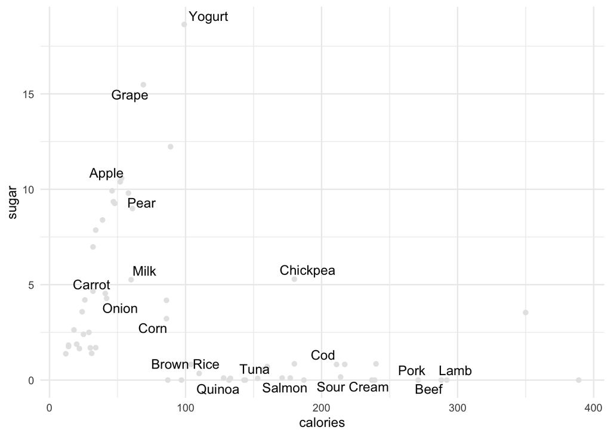

```r
food %>%
  ggplot(aes(calories, sugar)) +
    geom_point(color = "grey90") +
    geom_text_repel(aes(label = item), data = food_sample)
```

```r
ggsave(file.path("output", "figure01.png"), width = 6, height = 4, scale = 1.4)
```

Once saved, select the image in the file browser, select “More Options” and export the image to your local machine.

After you have a local version of the image, following the advice above you may want to add manual annotations. While it is possible to do this in R, it is usually nicer and easier to do in a different piece of software. On macOS, I find the Preview application to be easy and sufficient for most tasks. For more options and on Windows, you can pull the image into PowerPoint and annotate it there. The best option is to use something specifically designed for editing vector graphics, such as Adobe Illustrator, but these are usually expensive or difficult to install.

### Example

Let’s put together all of the elements in this chapter to produce a plot of wheat prices that highlights the differences in prices following WWI and following WWII. We will add a complete set of titles and captions. I selected the second color by picking the complementary color of the maroon used for the first time period.

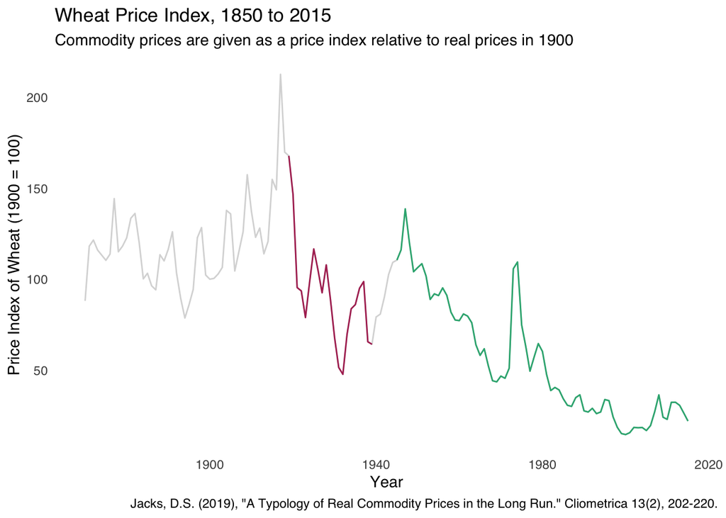

```r
food_prices %>%
  ggplot(aes(year, wheat)) +
    geom_line(color = "grey85") +
    geom_line(
      color = "maroon",
      data = filter(food_prices, between(year, 1919, 1939))
    ) +
    geom_line(
      color = "#30b080",
      data = filter(food_prices, between(year, 1945, 2015))
    ) +
    labs(
      title = "Wheat Price Index, 1850 to 2015",
      subtitle = "Commodity prices are given as a price index relative to real prices in 1900",
      caption = "Jacks, D.S. (2019), \"A Typology of Real Commodity Prices in the Long Run.\" Cliometrica 13(2), 202-220.",
      x = "Year",
      y = "Price Index of Wheat (1900 = 100)"
    ) +
    theme_sm()
```

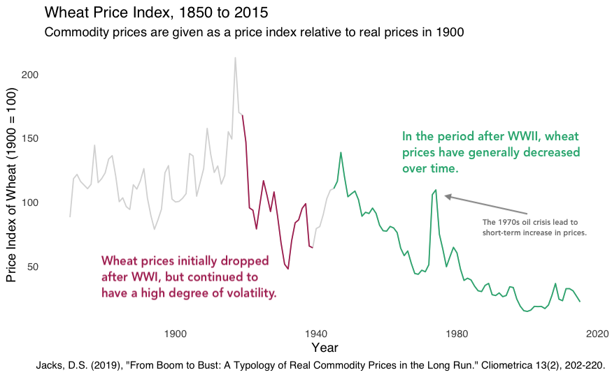

Notice that the plot both shows all of the data for the viewer, but guides them to the specific points of interest that we are interested. The sub point explaining the peak in the 1970s is shown in a smaller font size, and in a dark grey, because it is secondary to the points I wanted to make about the overall trends in the two post-war periods.

## Practice

For today’s practice, you are going to use the `foods` datatset to create an annotated graphic about your favorite food(s) (or at least, your favorite food that is in the dataset). In the code block below, produce a scatter plot of any two variables that you find interesting and highlight your favorite 1-3 food items. Use the `ggsave` function to export a version of the image into the output directory.

Once you have your image, download the file and add one or more manual annotations to the image.